# Malaria Detection

## **Executive Summary:**

### **Final proposed model specifications**

- Therefore, **EfficientNetB0 is selected as the final model**, as it provides:
  - High accuracy
  - Low false negatives
  - Good generalization
  - And practical deployability
  - Accuracy: 98%
  - Loss: 0.06
  - FN: 21 ; FP:31
  - Model size: 48.6 MB

**In conclusion, EfficientNetB0 delivers the best combination of diagnostic reliability and deployment readiness, making it the most suitable model for real-world malaria detection applications.**

## **Tabular Presentation of all models' metrics**

The table below summarizes all the metrics of all the models of this notebook for quick clarity

[output not shown]

## **Summary of the Problem definition:**

### **Context:**

Malaria remains a critical global health threat in 2026 `according World Malaria Report(2024) by the World Health Organization (WHO)`, because it can progress from mild flu-like symptoms to a fatal condition within 24 hours if untreated. Its danger stems from a multi-stage parasitic infection that systematically attacks vital bodily systems. Malaria had an estimated **282 million cases** and **610 000 deaths** in 2024 – roughly **9 million more cases** than the previous year.

### **Challenges:**

There are many challenges such as drug resistence, rising global burden, insecticide resistence etc. for Malaria. However, **there are two that equally crucial ones that as a data scientist and engineer can be addressed using the capabilities of neural network and deep learning**:

1. **Detection Challenges:** According to WHO World Malaria Report, the parasites have evolved and no longer produce the proteins targeted by standard Rapid Diagnostic Tests (RDTs), due to deletion of `pfhrp2/3` genes. *These gene deletions reduce or eliminate the target protein that HRP2-based RDTs detect, meaning infections can be missed by rapid tests*.

> According to WHO surveillance, these deletions have been confirmed in at least 40 countries, representing a significant global diagnostic challenge
2. **Field Realities:** In WHO E-2030 goals, it is stated that malaria depends on moving diagnosis out of big cities and into remote villages Eg, sub saharan Africa. Many remote clinics lack electricity for advanced lab gear.

### **How Deep learning models help overcome above to challenges:**

1. **Detection Challenges:** Unlike RDTs, image-based CNN models don’t rely on a single biochemical marker (like HRP2 protein).**They learn visual patterns of infected red blood cells, which still exist even if HRP2 isn’t expressed.** This means the model could catch infections that RDTs miss, especially in regions where mutated parasites are prevalent.
2. **Field Realities:** Modern CNNs can be **optimized into "lightweight" models** (like MobileNet or 2-layer architectures) that run locally on low-end smartphones. By attaching a smartphone to a basic microscope eyepiece, a community health worker can get a diagnostic result in minutes without needing an internet connection or expert advice.

## **Proposed Project Solution Pipeline**

1. Perform **Exploratory data analysis** on the given data set.
   - Perform data visualizations to understand the data better
   - Assert if any data preprocessing is needed, and if needed how to perform it.
2. **Model Development:** In this section, different models are trained and built to see which one is the best. In total of 5 models are being tried.
   - **Base Model**: Built from scratch, with focus on the given task of image classification keeping in mind its future deployablity on a resource constraint platform.
   - **Model_1**: Based on the performance of base model, more architectural based additions may be done in this model.
   - **Model_2**: Based on the performance of previous models, changes in dataset, or activiation function or architecture of the model will be done to see the differences.
   - **VGG-16**: This model is used to test transfer learning approach and see its benefits and performance with pre-trained model weights.
   - **EfficientNetB0:** Based on literature survey done for this capstone problem statement, it was discovered that this pre-trained model is used and tested before for this same task, and is lightweight for deployment. Hence in this notebook, this model is also implemented.
3. **Model Training**: Every aforementioned model is trained on the given dataset.
4. **Model Evaluation:** For model comparisons we use different performance evaluation values to assess different aspects of model's performance.
   - **Val_accuracy vs Training_accuracy charts**, to see if the model is overfitting or not based on any plausible gaps between both. See the overall performance over each epoch.
   - **Confusion matrix**, especially to see the false negatives since they are most important implying that patient was infected but not actually detected.
   - Classification report to understand the **precision**, **recall**, **f1 score** of the models for comparison
   - In the end we also plot a **ROC curve** and calculate the **AUC** of the curve to see the best performing model.
5. **Conclusion of the project:** In the end based on the results it is concluded which model is finalised.

## **Reasoning for the proposed solution:**

- The project helps find the better trade-off between a model that is deployable and efficiently identifies the image of a red blood cell as that of an infected one or not.
- In this pipeline, we compare the performance of different models using different performance metrics and then download and analyze the size of these models as well, to find the correct trade-off between a lightweight model and an accurate model.

## **How it would affect the problem/business?**

Based on the work done in the milestone project, it is revealed that the EfficientNet B0 is the model that provides the best performance on augmented data making the model robust and lightweight for deployment as well.

The solution of this project helps in solving the major two above mentioned challenges of the disease:

1. RDTs independent detection of Malaria
2. Deployment of the model to remote places like sub saharan africa in healthcare tools/wearables, where access to medical help and advanced lab gear is not easy.

## **Data Visualization**

In this section of the code, we will import the necessary libraries for the project, and then perform data exploration/visualization on them to better understand our data.

```python
#Importing the necessary libraries

import numpy as np
import matplotlib.pyplot as plt
import pandas as pd

import zipfile
import os
import random

import matplotlib.image as mpimg
```

```python
from google.colab import drive
drive.mount('/content/drive')
```

```python
#to preserve reproducibility of the code
SEED = 42
import tensorflow as tf
os.environ['PYTHONHASHSEED'] = str(SEED)
random.seed(SEED)
np.random.seed(SEED)
tf.random.set_seed(SEED)
```

```python
# Storing the path of the data file from the Google drive
path = '/content/drive/MyDrive/cell_images.zip'

# The data is provided as a zip file so we need to extract the files from the zip file
with zipfile.ZipFile(path, 'r') as zip_ref:
    zip_ref.extractall()
```

```python
# Parent directory where images are stored in drive
parent_dir = '/content/cell_images'

# Path to the training and testing datasets within the parent directory
train_dir = os.path.join(parent_dir, 'train')
test_dir = os.path.join(parent_dir, 'test')

# Directory with our training pictures
train_mal_dir = os.path.join(train_dir, 'parasitized')
train_no_mal_dir = os.path.join(train_dir, 'uninfected')

# Directory with our testing pictures
test_mal_dir = os.path.join(test_dir, 'parasitized')
test_no_mal_dir = os.path.join(test_dir, 'uninfected')
```

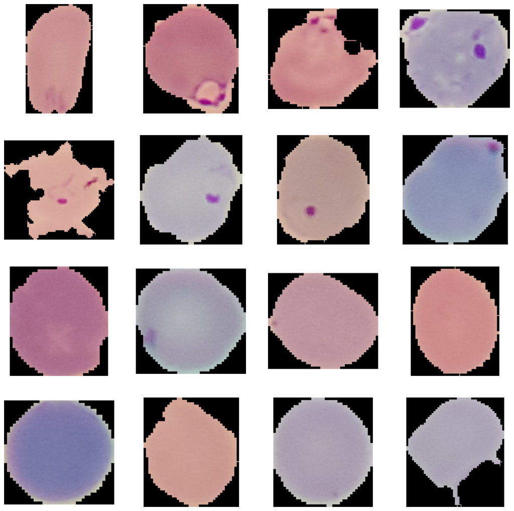

```python
#Lets first see the images

train_mal_fn = os.listdir(train_mal_dir)
train_no_mal_fn = os.listdir(train_no_mal_dir)

fig = plt.figure(figsize=(16, 8))
fig.set_size_inches(16, 16)

mal_img_paths = [os.path.join(train_mal_dir, file_name) for file_name in train_mal_fn[:8]]
no_mal_img_paths = [os.path.join(train_no_mal_dir, file_name) for file_name in train_no_mal_fn[:8]]

for i, img_path in enumerate(mal_img_paths + no_mal_img_paths):
    ax = plt.subplot(4, 4, i + 1)
    ax.axis('Off')

    img = mpimg.imread(img_path)
    plt.imshow(img)

plt.show()
```

```python
from PIL import Image
import os

shapes = set()

for img_name in os.listdir(train_mal_dir)[:50]:
    img_path = os.path.join(train_mal_dir, img_name)
    with Image.open(img_path) as img:
        shapes.add(img.size)

print("Unique image shapes:", shapes)
print ("Image Mode:", img.mode)
```

```
Unique image shapes: {(121, 112), (103, 100), (130, 112), (172, 157), (154, 115), (121, 124), (214, 193), (130, 130), (115, 172), (139, 127), (154, 133), (121, 130), (112, 127), (154, 130), (136, 124), (121, 133), (136, 127), (145, 145), (130, 154), (118, 103), (145, 151), (130, 166), (127, 124), (1…
Image Mode: RGB
```

#### **Observations & Insights:**

As we notice the size of all the images is not same, which is very crucial when working with CNNs. So we need to crop these images from the center to make sure they all have the same size as part of pre-processing

## **Data Exploration and Pre-Processing**

In this section, some basic info about the dataset, given.

1. Checking the shape of train and test images
2. Checking the shape of train and test labels
3. Checking the minimum and maximum range of pixel values for train and test images
4. Count the number of values in both uninfected and parasitized
5. Plot to check if the data is balanced, in the case it is imbalanced we can take steps to fix the same using different popular techinques.
6. Checking to see if normalization is needed or not
7. Reshape the images suitable for CNN models, as they expect same size.

```python
# Starting with the re-shaping first aka making every image of same input size (96x96)
from tensorflow.keras.preprocessing.image import ImageDataGenerator
```

```python
train_gen = ImageDataGenerator()
test_gen = ImageDataGenerator()
```

```python
train_generator = train_gen.flow_from_directory(
    train_dir,
    target_size=(96, 96),
    batch_size=16,
    class_mode='binary',
    subset='training',
    seed=SEED
)

test_generator = test_gen.flow_from_directory(
    test_dir,
    target_size=(96, 96),
    batch_size=16,
    class_mode='binary',
    shuffle= False,
    seed=SEED
)
```

```
Found 24958 images belonging to 2 classes.
Found 2600 images belonging to 2 classes.
```

```python
num_train = train_generator.samples
num_test = test_generator.samples

train_images = np.zeros((num_train, 96, 96, 3), dtype='float32')
train_labels = np.zeros((num_train,), dtype='float32')

i = 0
for imgs, lbls in train_generator:
    b = imgs.shape[0]
    train_images[i:i+b] = imgs
    train_labels[i:i+b] = lbls
    i += b
    if i >= num_train:
        break

test_images = np.zeros((num_test, 96, 96, 3), dtype='float32')
test_labels = np.zeros((num_test,), dtype='float32')

i = 0
for imgs, lbls in test_generator:
    b = imgs.shape[0]
    test_images[i:i+b] = imgs
    test_labels[i:i+b] = lbls
    i += b
    if i >= num_test:
        break
```

```python
print("Train images shape:", train_images.shape)
print("Train labels shape:", train_labels.shape)
print("Test images shape:", test_images.shape)
print("Test labels shape:", test_labels.shape)
```

```
Train images shape: (24958, 96, 96, 3)
Train labels shape: (24958,)
Test images shape: (2600, 96, 96, 3)
Test labels shape: (2600,)
```

#### **Observation & Insights:**

As displayed, it is noted that the train image shape implies that there are total `24958 images`, each of now same size `96x96 pixels` and `3 channels for RGB`.

Similarly, it is noted that the test image shape implies that there are total `2600 images`, each of now same size `96x96 pixels` and `3 channels for RGB`.

Plotting with labels after changing the size.

```python
print("Train image min/max pixels:", train_images.min(), train_images.max())
print("Test image min/max: pixels", test_images.min(), test_images.max())
```

```
Train image min/max pixels: 0.0 255.0
Test image min/max: pixels 0.0 255.0
```

#### **Observation & Insights:***

**Minimum Pixel Value:** The minimum pixel value for both the training and test images is 0.0.

**Maximum Pixel Value:** The maximum pixel value for both the training and test images is 255.0.

This indicates that the image data, has typical pixel range of 0 to 255 for standard 8-bit images. There is the need for the input images to be preprocessed and rescaled to a range of 0.0 to 1.0, making it suitable for training a neural network.

```python
print("Train label counts:\n", pd.Series(train_labels).value_counts())
print("Test label counts:\n", pd.Series(test_labels).value_counts())
```

```
Train label counts:
 0.0    12582
1.0    12376
Name: count, dtype: int64
Test label counts:
 0.0    1300
1.0    1300
Name: count, dtype: int64
```

#### **Observation & Insights:**

The dataset is **highly balanced** across both training and testing sets.

Testing Set: There is a perfect *50/50 split*, with exactly `1,300 samples for each class.`

**Implications:**

- The model is `unlikely to develop a majority-class bias`, as it will receive equal exposure to both classes during training.
- `Accuracy will be a reliable performance metric` in this case. Unlike imbalanced datasets, where a model can achieve high accuracy by simply guessing the majority class, here a high accuracy score will truly reflect the model's ability to distinguish between classes.
- Other than normalization, resizing and potential data augmentation in any future model, there isn't any explicit pre-processing required to be done on the provided dataset.

```python
#Normalizing
train_gen = ImageDataGenerator(rescale=1.0 / 255.0)
test_gen = ImageDataGenerator(rescale=1.0 / 255.0)
```

```python
train_generator = train_gen.flow_from_directory(
    train_dir,
    target_size=(96, 96),
    batch_size=16,
    class_mode='binary',
    subset='training',
    seed=SEED
)

test_generator = test_gen.flow_from_directory(
    test_dir,
    target_size=(96, 96),
    batch_size=16,
    class_mode='binary',
    shuffle= False,
    seed=SEED
)
```

```
Found 24958 images belonging to 2 classes.
Found 2600 images belonging to 2 classes.
```

```python
print("Class indices:", train_generator.class_indices)
```

```
Class indices: {'parasitized': 0, 'uninfected': 1}
```

```python
print("Class indices:", train_generator.class_indices)

idx_to_class = {v: k for k, v in train_generator.class_indices.items()}
```

```
Class indices: {'parasitized': 0, 'uninfected': 1}
```

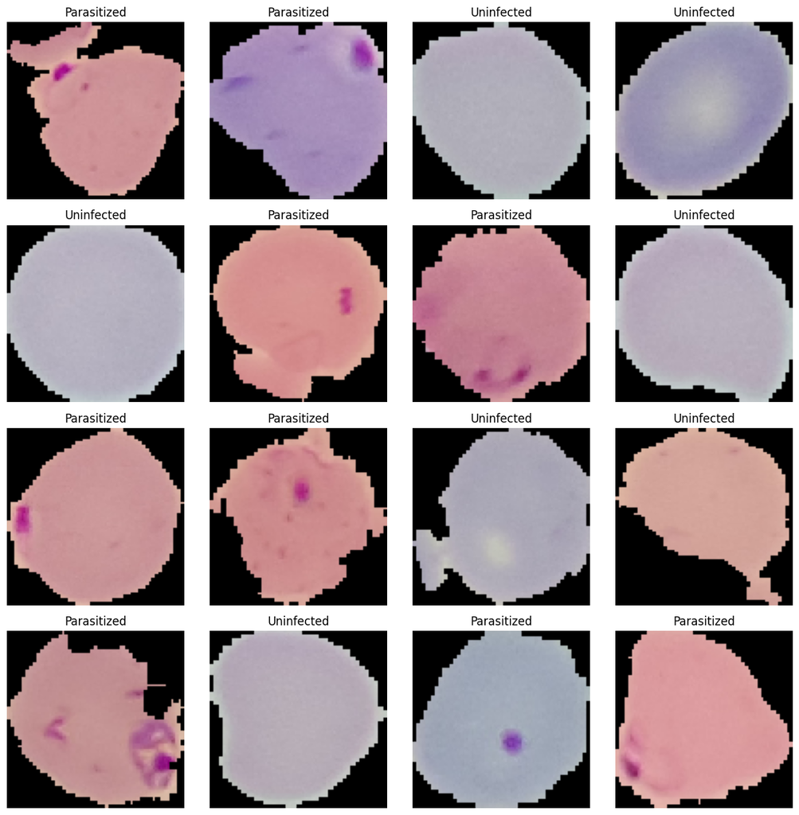

```python
images, labels = next(train_generator)

fig, axes = plt.subplots(4, 4, figsize=(12, 12))

for img, label, ax in zip(images, labels, axes.flatten()):
    ax.imshow(img)
    ax.set_title(idx_to_class[int(label)].capitalize())
    ax.axis("off")

plt.tight_layout()
plt.show()
```

#### **Observation & Insights:**

We can see that the images are now of all the same size, labelled and normalized

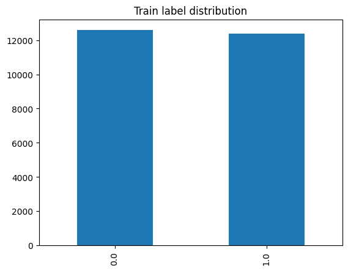

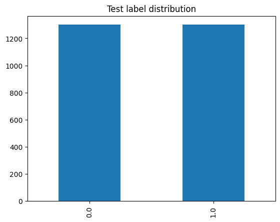

```python
#Lets plot to see the balanced visualized
pd.Series(train_labels).value_counts().plot(kind='bar', title='Train label distribution')
plt.show()

pd.Series(test_labels).value_counts().plot(kind='bar', title='Test label distribution')
plt.show()
```

#### **Observation & Insights**

The plot is simply reflecting the above mentioned attributes visually as well, thereby confirming the insights and observations.

```python
# Function to find the mean
def find_mean_img(full_mat, title):

    # Calculate the average
    mean_img = np.mean(full_mat, axis = 0)[0]

    # Reshape it back to a matrix
    plt.imshow(mean_img)

    plt.title(f'Average {title}')

    plt.axis('off')

    plt.show()

    return mean_img
```

```python
num_train = train_generator.samples
num_test = test_generator.samples

train_images = np.zeros((num_train, 96, 96, 3), dtype='float32')
train_labels = np.zeros((num_train,), dtype='float32')

i = 0
for imgs, lbls in train_generator:
    b = imgs.shape[0]
    train_images[i:i+b] = imgs
    train_labels[i:i+b] = lbls
    i += b
    if i >= num_train:
        break

test_images = np.zeros((num_test, 96, 96, 3), dtype='float32')
test_labels = np.zeros((num_test,), dtype='float32')

i = 0
for imgs, lbls in test_generator:
    b = imgs.shape[0]
    test_images[i:i+b] = imgs
    test_labels[i:i+b] = lbls
    i += b
    if i >= num_test:
        break
```

```python
# If the label = 1 then the image is parasitised and if the label = 0 then the image is uninfected
parasitized_data = []  # Create a list to store the parasitized data
no_mal_data = []
for img, label in zip(train_images, train_labels):
  class_name = idx_to_class[int(label)]
  if class_name == 'parasitized':
    parasitized_data.append([img])
  elif class_name == 'uninfected':
    no_mal_data.append([img])
```

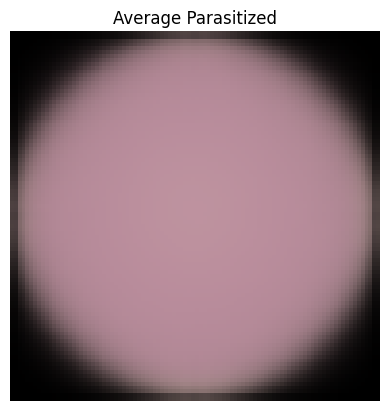

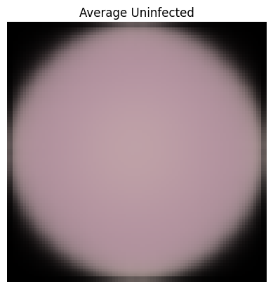

```python
parasitized_mean = find_mean_img(
    np.array(parasitized_data),
    'Parasitized'
)

uninfected_mean = find_mean_img(
    np.array(no_mal_data),
    'Uninfected'
)
```

#### **Observation & Insights**

- Clearly applying mean to the image is not useful, as it removes the textural and edge based varience in the image between the unifected and infected image. Making it hard for the model to learn anything for the distinguishing.
- **Note#1:** Gaussian blurring was not applied as a standard preprocessing step, as malaria parasite detection relies on fine-grained texture and morphological features that may be suppressed by smoothing operations. Since convolutional neural networks are inherently capable of learning noise-robust representations, blurring was instead considered only as a mild data augmentation technique to simulate focus variability in microscopy images.
- **Note #2:** Since this is a binary classification problem, labels are kept in binary format (0/1) and a sigmoid activation with binary cross-entropy loss is used.

## **Model Building**

Now that the data preprocessing and exploration is done, next step is to build various Convolutional Neural Network (CNN) models to see the performance of the models and better choose the one deploying.

To acheive fairness in different models' comparison, it is carefully ensured that all models were **trained under identical experimental conditions.**

These include:

1. Same train/val split (80-20)
2. Same optimizer (Adam, LR= 0.0001)
3. Same BATCH_SIZE (16)
4. Same IMAGE_SIZE (96x96)
5. Same NO_OF_EPOCHS (7)
6. Same Loss Function = binary_crossentropy
7. Same Callbacks Logic
   - Patience = 5
   - Monitor = val_loss (Early Stopping, when applied)
   - Monitor = val_accuracy (ModelCheckpoint, when applied)

**The improvement in the model is noted via:**

1. Architecture depth
2. Number of filters
3. Activation functions
4. Batch Normalization
5. Data augmentation
6. Transfer learning vs scratch
7. Using different pretrained models

### **Base Model:**

The proposed base **CNN model** is a relatively simple but effective deep learning architecture for binary image classification (Parasitized vs Uninfected red blood cells).

- The model uses **three convolutional blocks** with increasing filter sizes (32 → 64 → 128), allowing it to:
  - Capture low-level features such as edges and textures in early layers.
  - Learn higher-level spatial patterns such as parasite shapes and cell abnormalities in deeper layers.
- **MaxPooling layers** reduce spatial dimensions, helping:
  - Lower computational cost
  - Improve translation invariance
- The **fully connected dense layer (128 neurons)** combines extracted features for decision-making.
- The final sigmoid activation outputs a probability for binary classification.

```python
train_val_gen = ImageDataGenerator(rescale=1.0 / 255.0,validation_split=0.2)
```

```python
# rewriting for validation
train_generator = train_val_gen.flow_from_directory(
    train_dir,
    target_size=(96, 96),
    batch_size=16,
    class_mode='binary',
    subset='training',
    seed=SEED
)

val_generator = train_val_gen.flow_from_directory(
    train_dir,
    target_size=(96, 96),
    batch_size=16,
    class_mode='binary',
    subset='validation',
    seed=SEED
)
```

```
Found 19967 images belonging to 2 classes.
Found 4991 images belonging to 2 classes.
```

```python
#clearing the backend for better performance
from tensorflow.keras import backend
backend.clear_session()
```

```python
from tensorflow.keras.models import Sequential
from tensorflow.keras.layers import Conv2D, MaxPooling2D, Flatten, Dense
from tensorflow.keras.optimizers import Adam
```

```python
# Build base CNN model
base_model = Sequential([

    Conv2D(32, (3, 3), activation='relu', input_shape=(96, 96, 3), padding = 'same'),
    MaxPooling2D(pool_size=(2, 2)),

    Conv2D(64, (3, 3), activation='relu',padding = 'same'),
    MaxPooling2D(pool_size=(2, 2)),

    Conv2D(128, (3, 3), activation='relu',padding = 'same'),
    MaxPooling2D(pool_size=(2, 2)),

    Flatten(),

    Dense(128, activation='relu'),

    Dense(1, activation='sigmoid')
])
```

```python
base_model.summary()
```

```
Model: "sequential"
```

```
┏━━━━━━━━━━━━━━━━━━━━━━━━━━━━━━━━━┳━━━━━━━━━━━━━━━━━━━━━━━━┳━━━━━━━━━━━━━━━┓
┃ Layer (type)                    ┃ Output Shape           ┃       Param # ┃
┡━━━━━━━━━━━━━━━━━━━━━━━━━━━━━━━━━╇━━━━━━━━━━━━━━━━━━━━━━━━╇━━━━━━━━━━━━━━━┩
│ conv2d (Conv2D)                 │ (None, 96, 96, 32)     │           896 │
├─────────────────────────────────┼────────────────────────┼───────────────┤
│ max_pooling2d (MaxPooling2D)    │ (None, 48, 48, 32)     │             0 │
├─────────────────────────────────┼────────────────────────┼───────────────┤
│ conv2d_1 (Conv2D)               │ (None, 48, 48, 64)     │        18,496 │
├─────────────────────────────────┼────────────────────────┼───────────────┤
│ max_pooling2d_1 (MaxPooling2D)  │ (None, 24, 24, 64)     │             0 │
├─────────────────────────────────┼────────────────────────┼───────────────┤
│ conv2d_2 (Conv2D)               │ (None, 24, 24, 128)    │        73,856 │
├─────────────────────────────────┼────────────────────────┼───────────────┤
│ max_pooling2d_2 (MaxPooling2D)  │ (None, 12, 12, 128)    │             0 │
├─────────────────────────────────┼────────────────────────┼───────────────┤
│ flatten (Flatten)               │ (None, 18432)          │             0 │
├─────────────────────────────────┼────────────────────────┼───────────────┤
│ dense (Dense)                   │ (None, 128)            │     2,359,424 │
├─────────────────────────────────┼────────────────────────┼───────────────┤
│ dense_1 (Dense)                 │ (None, 1)              │           129 │
└─────────────────────────────────┴────────────────────────┴───────────────┘
```

```
 Total params: 2,452,801 (9.36 MB)
```

```
 Trainable params: 2,452,801 (9.36 MB)
```

```
 Non-trainable params: 0 (0.00 B)
```

#### **Observation & Insights**

- There are total 2,452,801 trainable parameters making it better for overall learning
- However, the size of the model is quiet high 9.36 MB making it hard for deployment on remote devices. We can make sure if such is the case for other models.

```python
# Compile the model
base_model.compile(optimizer=Adam(learning_rate=0.0001), loss='binary_crossentropy', metrics=['accuracy'])
```

```python
history_base_model = base_model.fit(
    train_generator,
    validation_data=val_generator,
    epochs=7
)
```

```
1248/1248 ━━━━━━━━━━━━━━━━━━━━ 48s 34ms/step - accuracy: 0.6865 - loss: 0.5814 - val_accuracy: 0.9066 - val_loss: 0.2360
1248/1248 ━━━━━━━━━━━━━━━━━━━━ 40s 32ms/step - accuracy: 0.9378 - loss: 0.1767 - val_accuracy: 0.9497 - val_loss: 0.1346
1248/1248 ━━━━━━━━━━━━━━━━━━━━ 35s 28ms/step - accuracy: 0.9645 - loss: 0.1098 - val_accuracy: 0.9577 - val_loss: 0.1172
1248/1248 ━━━━━━━━━━━━━━━━━━━━ 42s 33ms/step - accuracy: 0.9727 - loss: 0.0846 - val_accuracy: 0.9639 - val_loss: 0.0947
1248/1248 ━━━━━━━━━━━━━━━━━━━━ 39s 32ms/step - accuracy: 0.9764 - loss: 0.0699 - val_accuracy: 0.9651 - val_loss: 0.0915
1248/1248 ━━━━━━━━━━━━━━━━━━━━ 32s 25ms/step - accuracy: 0.9798 - loss: 0.0648 - val_accuracy: 0.9539 - val_loss: 0.1162
1248/1248 ━━━━━━━━━━━━━━━━━━━━ 37s 30ms/step - accuracy: 0.9822 - loss: 0.0543 - val_accuracy: 0.9685 - val_loss: 0.0874
```

```python
base_model.evaluate(test_generator)
```

```
163/163 ━━━━━━━━━━━━━━━━━━━━ 3s 21ms/step - accuracy: 0.9799 - loss: 0.0596
```

```
[0.08041746914386749, 0.9742307662963867]
```

#### **Observation**

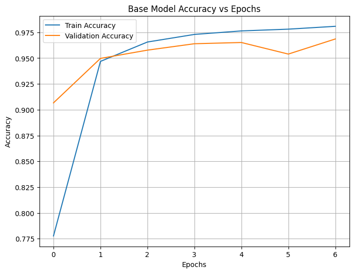

```python
plt.figure(figsize=(8, 6))

plt.plot(history_base_model.history['accuracy'], label='Train Accuracy')
plt.plot(history_base_model.history['val_accuracy'], label='Validation Accuracy')

plt.title('Base Model Accuracy vs Epochs')
plt.xlabel('Epochs')
plt.ylabel('Accuracy')
plt.legend()
plt.grid(True)

plt.show()
```

```python
class_indices = test_generator.class_indices
idx_to_class = {v: k for k, v in class_indices.items()}

labels_order = [idx_to_class[i].capitalize() for i in range(len(idx_to_class))]
print("Confusion matrix label order:", labels_order)
```

```
Confusion matrix label order: ['Parasitized', 'Uninfected']
```

```python
from tensorflow.keras.models import load_model

model_1 = load_model('model_1_best.h5')
model_2 = load_model('model_2_best.h5')
model_vgg16 = load_model('vgg16_best.h5')
model_effnet = load_model('efficientnetb0_malaria.h5')
```

```python
from sklearn.metrics import confusion_matrix, classification_report
import seaborn as sns

# Reset generator to avoid shuffling issues
test_generator.reset()

# Predict probabilities
y_pred_prob = base_model.predict(test_generator)

# Convert probabilities to class labels (0 or 1)
y_pred = (y_pred_prob > 0.5).astype(int).ravel()

# True labels
y_true = test_generator.classes
```

```
163/163 ━━━━━━━━━━━━━━━━━━━━ 6s 29ms/step
```

[figure not shown]

```python
cm = confusion_matrix(y_true, y_pred)

plt.figure(figsize=(6, 5))
sns.heatmap(cm, annot=True, fmt='d', cmap='Blues',
            xticklabels=labels_order,
            yticklabels=labels_order)

plt.xlabel('Predicted Label')
plt.ylabel('True Label')
plt.title('Confusion Matrix - Base Model')
plt.show()
```

#### **Observations & Insights:**

- For any medical diagnosis project, taking look at the false negatives is crucial as that means these many patients were not detected when they actually had Malaria. And in the current model this number is very high.
- We must focus in the upcoming model variations to see if this number is decreased or not.

```python
print(classification_report(
    y_true,
    y_pred,
    target_names=['Uninfected', 'Parasitized']
))
```

```
              precision    recall  f1-score   support

  Uninfected       0.96      0.99      0.97      1300
 Parasitized       0.99      0.96      0.97      1300

    accuracy                           0.97      2600
   macro avg       0.97      0.97      0.97      2600
weighted avg       0.97      0.97      0.97      2600
```

#### **Observation & Insights:**

`From the accuracy vs epochs plot:`

- Training accuracy increases rapidly from ~77% to ~98%
- Validation accuracy closely follows training accuracy and stabilizes around 96–97%
- The small gap between training and validation curves indicates:
  - Good generalization
  - No significant overfitting
- The validation accuracy continues to improve gradually, suggesting the model learns meaningful features rather than memorizing data.

**Precision (0.99)**

Indicates low false-positive rate.

**Recall (0.96)**

Very important for malaria screening to avoid missing infected cases.

**Conclusion:** The model converges well and maintains stable performance on unseen data for a base model. **The dataset is highly balanced and well-curated, which makes the classification task less noisy and allows the model to achieve high performance**.

It would be interesting to see if adding Batch Normalization and LeakyReLU changes the accuracy more or not. Hence we move towards the next model Model_1

## **Model 1**

### Architectural Changes and Their Purpose

Compared to the base CNN, **Model-1 introduces three key improvements** aimed at better robustness and real-world applicability:

### (a) Batch Normalization

- Added after every convolutional and dense layer
- Stabilizes activation distributions during training
- Allows higher learning rates and faster convergence

### (b) LeakyReLU Activation

- Replaces ReLU to avoid the *dying ReLU* problem
- Maintains small gradients for negative inputs
- Improves gradient flow, especially in deeper networks

### (c) Increased Depth

- More convolutional layers (5 conv blocks vs 3 in base model)
- Enables learning of more **complex and hierarchical features**
- Makes the model more expressive and closer in spirit to VGG-style architectures

### (d) ModelCheckpoint

- Ensures the best-performing model (on validation data) is saved
- Prevents degradation due to late-epoch overfitting

```python
from tensorflow.keras import backend
backend.clear_session()
```

```python
from tensorflow.keras.layers import BatchNormalization, LeakyReLU
```

```python
model_1 = Sequential([

    Conv2D(32, (3, 3), padding='same', input_shape=(96, 96, 3)),
    BatchNormalization(),
    LeakyReLU(negative_slope=0.1),
    MaxPooling2D(pool_size=(2, 2)),

    Conv2D(32, (3, 3), padding='same'),
    BatchNormalization(),
    LeakyReLU(negative_slope=0.1),
    MaxPooling2D(pool_size=(2, 2)),

    Conv2D(64, (3, 3), padding='same'),
    BatchNormalization(),
    LeakyReLU(negative_slope=0.1),
    MaxPooling2D(pool_size=(2, 2)),

    Conv2D(64, (3, 3), padding='same'),
    BatchNormalization(),
    LeakyReLU(negative_slope=0.1),
    MaxPooling2D(pool_size=(2, 2)),

    Conv2D(128, (3, 3), padding='same'),
    BatchNormalization(),
    LeakyReLU(negative_slope=0.1),
    MaxPooling2D(pool_size=(2, 2)),

    Flatten(),

    Dense(128),
    BatchNormalization(),
    LeakyReLU(negative_slope=0.1),

    Dense(1, activation='sigmoid')
])
```

```python
model_1.summary()
```

```
Model: "sequential"
```

```
┏━━━━━━━━━━━━━━━━━━━━━━━━━━━━━━━━━┳━━━━━━━━━━━━━━━━━━━━━━━━┳━━━━━━━━━━━━━━━┓
┃ Layer (type)                    ┃ Output Shape           ┃       Param # ┃
┡━━━━━━━━━━━━━━━━━━━━━━━━━━━━━━━━━╇━━━━━━━━━━━━━━━━━━━━━━━━╇━━━━━━━━━━━━━━━┩
│ conv2d (Conv2D)                 │ (None, 96, 96, 32)     │           896 │
├─────────────────────────────────┼────────────────────────┼───────────────┤
│ batch_normalization             │ (None, 96, 96, 32)     │           128 │
│ (BatchNormalization)            │                        │               │
├─────────────────────────────────┼────────────────────────┼───────────────┤
│ leaky_re_lu (LeakyReLU)         │ (None, 96, 96, 32)     │             0 │
├─────────────────────────────────┼────────────────────────┼───────────────┤
│ max_pooling2d (MaxPooling2D)    │ (None, 48, 48, 32)     │             0 │
├─────────────────────────────────┼────────────────────────┼───────────────┤
│ conv2d_1 (Conv2D)               │ (None, 48, 48, 32)     │         9,248 │
├─────────────────────────────────┼────────────────────────┼───────────────┤
│ batch_normalization_1           │ (None, 48, 48, 32)     │           128 │
│ (BatchNormalization)            │                        │               │
├─────────────────────────────────┼────────────────────────┼───────────────┤
│ leaky_re_lu_1 (LeakyReLU)       │ (None, 48, 48, 32)     │             0 │
├─────────────────────────────────┼────────────────────────┼───────────────┤
│ max_pooling2d_1 (MaxPooling2D)  │ (None, 24, 24, 32)     │             0 │
├─────────────────────────────────┼────────────────────────┼───────────────┤
│ conv2d_2 (Conv2D)               │ (None, 24, 24, 64)     │        18,496 │
├─────────────────────────────────┼────────────────────────┼───────────────┤
│ batch_normalization_2           │ (None, 24, 24, 64)     │           256 │
│ (BatchNormalization)            │                        │               │
├─────────────────────────────────┼────────────────────────┼───────────────┤
│ leaky_re_lu_2 (LeakyReLU)       │ (None, 24, 24, 64)     │             0 │
├─────────────────────────────────┼────────────────────────┼───────────────┤
│ max_pooling2d_2 (MaxPooling2D)  │ (None, 12, 12, 64)     │             0 │
├─────────────────────────────────┼────────────────────────┼───────────────┤
│ conv2d_3 (Conv2D)               │ (None, 12, 12, 64)     │        36,928 │
├─────────────────────────────────┼────────────────────────┼───────────────┤
│ batch_normalization_3           │ (None, 12, 12, 64)     │           256 │
│ (BatchNormalization)            │                        │               │
├─────────────────────────────────┼────────────────────────┼───────────────┤
│ leaky_re_lu_3 (LeakyReLU)       │ (None, 12, 12, 64)     │             0 │
├─────────────────────────────────┼────────────────────────┼───────────────┤
│ max_pooling2d_3 (MaxPooling2D)  │ (None, 6, 6, 64)       │             0 │
├─────────────────────────────────┼────────────────────────┼───────────────┤
│ conv2d_4 (Conv2D)               │ (None, 6, 6, 128)      │        73,856 │
├─────────────────────────────────┼────────────────────────┼───────────────┤
│ batch_normalization_4           │ (None, 6, 6, 128)      │           512 │
│ (BatchNormalization)            │                        │               │
├─────────────────────────────────┼────────────────────────┼───────────────┤
│ leaky_re_lu_4 (LeakyReLU)       │ (None, 6, 6, 128)      │             0 │
├─────────────────────────────────┼────────────────────────┼───────────────┤
│ max_pooling2d_4 (MaxPooling2D)  │ (None, 3, 3, 128)      │             0 │
├─────────────────────────────────┼────────────────────────┼───────────────┤
│ flatten (Flatten)               │ (None, 1152)           │             0 │
├─────────────────────────────────┼────────────────────────┼───────────────┤
│ dense (Dense)                   │ (None, 128)            │       147,584 │
├─────────────────────────────────┼────────────────────────┼───────────────┤
│ batch_normalization_5           │ (None, 128)            │           512 │
│ (BatchNormalization)            │                        │               │
├─────────────────────────────────┼────────────────────────┼───────────────┤
│ leaky_re_lu_5 (LeakyReLU)       │ (None, 128)            │             0 │
├─────────────────────────────────┼────────────────────────┼───────────────┤
│ dense_1 (Dense)                 │ (None, 1)              │           129 │
└─────────────────────────────────┴────────────────────────┴───────────────┘
```

```
 Total params: 288,929 (1.10 MB)
```

```
 Trainable params: 288,033 (1.10 MB)
```

```
 Non-trainable params: 896 (3.50 KB)
```

#### **Observations and Insights:**

Due to decrease in the learnable parameters, the size of the model has also decreased significantly, which can be useful for deployabilty of the model.

The accuracy and overall performance metrics of this model would reveal more insights.

```python
from tensorflow.keras.callbacks import ModelCheckpoint
```

```python
#choosing accuracy to monitor as discussed above that in a clean balanced dataset accuracy will become the true performance metric
mc = ModelCheckpoint('model_1_best.h5', monitor='val_accuracy', mode= 'max', save_best_only=True, verbose=1)
```

```python
model_1.compile(optimizer=Adam(learning_rate=0.0001), loss='binary_crossentropy',metrics=['accuracy'])
```

```python
history_model_1 = model_1.fit(
    train_generator,
    validation_data=val_generator,
    epochs=7,
    callbacks=[mc]
)
```

```
1248/1248 ━━━━━━━━━━━━━━━━━━━━ 0s 30ms/step - accuracy: 0.8011 - loss: 0.4051
Epoch 1: val_accuracy improved from -inf to 0.95151, saving model to model_1_best.h5
```

```
WARNING:absl:You are saving your model as an HDF5 file via `model.save()` or `keras.saving.save_model(model)`. This file format is considered legacy. We recommend using instead the native Keras format, e.g. `model.save('my_model.keras')` or `keras.saving.save_model(model, 'my_model.keras')`.
```

```
1248/1248 ━━━━━━━━━━━━━━━━━━━━ 55s 36ms/step - accuracy: 0.8012 - loss: 0.4050 - val_accuracy: 0.9515 - val_loss: 0.1250
1246/1248 ━━━━━━━━━━━━━━━━━━━━ 0s 26ms/step - accuracy: 0.9615 - loss: 0.1131
Epoch 2: val_accuracy improved from 0.95151 to 0.96414, saving model to model_1_best.h5
```

```
WARNING:absl:You are saving your model as an HDF5 file via `model.save()` or `keras.saving.save_model(model)`. This file format is considered legacy. We recommend using instead the native Keras format, e.g. `model.save('my_model.keras')` or `keras.saving.save_model(model, 'my_model.keras')`.
```

```
1248/1248 ━━━━━━━━━━━━━━━━━━━━ 38s 31ms/step - accuracy: 0.9615 - loss: 0.1131 - val_accuracy: 0.9641 - val_loss: 0.1020
1248/1248 ━━━━━━━━━━━━━━━━━━━━ 0s 25ms/step - accuracy: 0.9711 - loss: 0.0890
Epoch 3: val_accuracy improved from 0.96414 to 0.97315, saving model to model_1_best.h5
```

```
WARNING:absl:You are saving your model as an HDF5 file via `model.save()` or `keras.saving.save_model(model)`. This file format is considered legacy. We recommend using instead the native Keras format, e.g. `model.save('my_model.keras')` or `keras.saving.save_model(model, 'my_model.keras')`.
```

```
1248/1248 ━━━━━━━━━━━━━━━━━━━━ 39s 31ms/step - accuracy: 0.9711 - loss: 0.0890 - val_accuracy: 0.9732 - val_loss: 0.0702
1247/1248 ━━━━━━━━━━━━━━━━━━━━ 0s 24ms/step - accuracy: 0.9775 - loss: 0.0711
Epoch 4: val_accuracy did not improve from 0.97315
1248/1248 ━━━━━━━━━━━━━━━━━━━━ 37s 29ms/step - accuracy: 0.9775 - loss: 0.0711 - val_accuracy: 0.9633 - val_loss: 0.0899
1246/1248 ━━━━━━━━━━━━━━━━━━━━ 0s 22ms/step - accuracy: 0.9792 - loss: 0.0645
Epoch 5: val_accuracy improved from 0.97315 to 0.97495, saving model to model_1_best.h5
```

```
WARNING:absl:You are saving your model as an HDF5 file via `model.save()` or `keras.saving.save_model(model)`. This file format is considered legacy. We recommend using instead the native Keras format, e.g. `model.save('my_model.keras')` or `keras.saving.save_model(model, 'my_model.keras')`.
```

```
1248/1248 ━━━━━━━━━━━━━━━━━━━━ 32s 26ms/step - accuracy: 0.9792 - loss: 0.0645 - val_accuracy: 0.9750 - val_loss: 0.0692
1248/1248 ━━━━━━━━━━━━━━━━━━━━ 0s 28ms/step - accuracy: 0.9831 - loss: 0.0504
Epoch 6: val_accuracy improved from 0.97495 to 0.97556, saving model to model_1_best.h5
```

```
WARNING:absl:You are saving your model as an HDF5 file via `model.save()` or `keras.saving.save_model(model)`. This file format is considered legacy. We recommend using instead the native Keras format, e.g. `model.save('my_model.keras')` or `keras.saving.save_model(model, 'my_model.keras')`.
```

```
1248/1248 ━━━━━━━━━━━━━━━━━━━━ 41s 33ms/step - accuracy: 0.9831 - loss: 0.0504 - val_accuracy: 0.9756 - val_loss: 0.0643
1248/1248 ━━━━━━━━━━━━━━━━━━━━ 0s 21ms/step - accuracy: 0.9840 - loss: 0.0465
Epoch 7: val_accuracy did not improve from 0.97556
1248/1248 ━━━━━━━━━━━━━━━━━━━━ 32s 25ms/step - accuracy: 0.9840 - loss: 0.0465 - val_accuracy: 0.9673 - val_loss: 0.0799
```

```python
from tensorflow.keras.models import load_model
model_1= load_model("model_1_best.h5")
model_1.evaluate(test_generator)
```

```
WARNING:absl:Compiled the loaded model, but the compiled metrics have yet to be built. `model.compile_metrics` will be empty until you train or evaluate the model.
```

```
163/163 ━━━━━━━━━━━━━━━━━━━━ 6s 31ms/step - accuracy: 0.9795 - loss: 0.0492
```

```
[0.04265696555376053, 0.983846127986908]
```

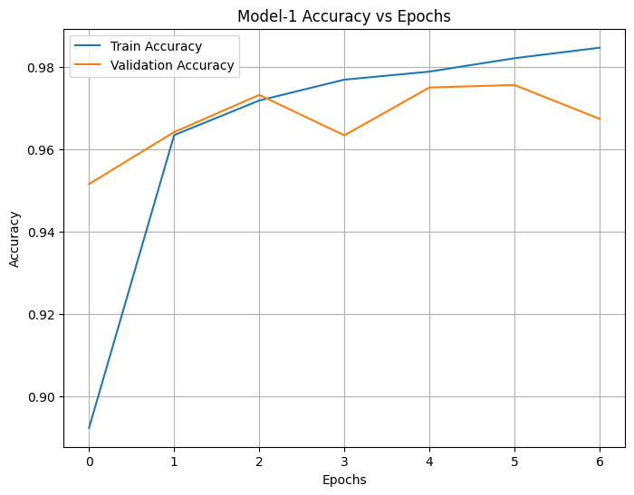

```python
plt.figure(figsize=(8, 6))

plt.plot(history_model_1.history['accuracy'], label='Train Accuracy')
plt.plot(history_model_1.history['val_accuracy'], label='Validation Accuracy')

plt.title('Model-1 Accuracy vs Epochs')
plt.xlabel('Epochs')
plt.ylabel('Accuracy')
plt.legend()
plt.grid(True)

plt.show()
```

```python
test_generator.reset()

y_pred_prob_1 = model_1.predict(test_generator)
y_pred_1 = (y_pred_prob_1 > 0.5).astype(int).ravel()

y_true = test_generator.classes
```

```
163/163 ━━━━━━━━━━━━━━━━━━━━ 4s 19ms/step
```

[figure not shown]

```python
cm_1 = confusion_matrix(y_true, y_pred_1)

plt.figure(figsize=(6, 5))
sns.heatmap(
    cm_1,
    annot=True,
    fmt='d',
    cmap='Blues',
    xticklabels=labels_order,
    yticklabels=labels_order
)

plt.xlabel('Predicted Label')
plt.ylabel('True Label')
plt.title('Confusion Matrix – Model-1')
plt.show()
```

#### **Observation:**

The false positives have increased, however it seems better trade off, as false negatives are far more dangerous.

```python
print(classification_report(
    y_true,
    y_pred_1,
    target_names=['Uninfected', 'Parasitized']
))
```

```
              precision    recall  f1-score   support

  Uninfected       0.99      0.98      0.98      1300
 Parasitized       0.98      0.99      0.98      1300

    accuracy                           0.98      2600
   macro avg       0.98      0.98      0.98      2600
weighted avg       0.98      0.98      0.98      2600
```

#### **Observation & Insights:**

**Next Steps:**

Although the dataset is clean and balanced, real-world blood smear images often vary in illumination, orientation, staining, and noise. Data augmentation artificially introduces such variations, helping the model learn more generalizable features rather than relying on dataset-specific patterns. This improves robustness when the model is applied to unseen or real clinical data.

Hence the next model will be fed augmentated data, along with also applying early stopping to perserve model computation resources.

### **Model 2**

```python
from tensorflow.keras import backend
backend.clear_session()
```

Data Augmentation:

```python
train_datagen = ImageDataGenerator(
    rescale=1.0 / 255.0,
    validation_split=0.2,
    horizontal_flip=True,
    rotation_range=20,
    width_shift_range=0.1,
    height_shift_range=0.1,
    shear_range=0.1,
    zoom_range=0.1
)

val_datagen = ImageDataGenerator(
    rescale=1.0 / 255.0,
    validation_split=0.2
)
```

```python
train_generator = train_datagen.flow_from_directory(
    train_dir,
    target_size=(96, 96),
    batch_size=16,
    class_mode='binary',
    subset='training',
    seed=SEED
)
val_generator = val_datagen.flow_from_directory(
    train_dir,
    target_size=(96, 96),
    batch_size=16,
    class_mode='binary',
    subset='validation',
    seed=SEED
)
```

```
Found 19967 images belonging to 2 classes.
Found 4991 images belonging to 2 classes.
```

### Model-2 (Hybrid Pooling CNN) – Architecture Description

This model extends the previous CNN by using **hybrid pooling**, where **Max Pooling and Average Pooling** are applied in parallel after each convolution block and their outputs are concatenated. Max Pooling helps capture the most prominent parasite-related features, while Average Pooling preserves overall texture and contextual information of red blood cells.

Each block consists of **Conv2D + Batch Normalization + LeakyReLU**, which improves training stability, prevents dying ReLU issues, and reduces overfitting. The increasing number of filters (32 → 64 → 128) allows the model to learn progressively more complex features.

By combining pooled features through concatenation, the model retains richer representations without significantly increasing depth. The final dense layers perform binary classification using a sigmoid activation.

Overall, this architecture is designed to be **more robust to real-world variations** (noise, illumination, staining differences) compared to simpler CNNs, while still remaining lightweight.

```python
from tensorflow.keras.layers import AveragePooling2D, Concatenate,Input
from tensorflow.keras.models import Model

input_layer = Input(shape=(96, 96, 3))

# ---- Block 1 ----
x = Conv2D(32, (3,3), padding='same')(input_layer)
x = BatchNormalization()(x)
x = LeakyReLU(negative_slope=0.1)(x)

max_p = MaxPooling2D(pool_size=(2,2))(x)
avg_p = AveragePooling2D(pool_size=(2,2))(x)
x = Concatenate()([max_p, avg_p])

# ---- Block 2 ----
x = Conv2D(64, (3,3), padding='same')(x)
x = BatchNormalization()(x)
x = LeakyReLU(negative_slope=0.1)(x)

max_p = MaxPooling2D(pool_size=(2,2))(x)
avg_p = AveragePooling2D(pool_size=(2,2))(x)
x = Concatenate()([max_p, avg_p])

# ---- Block 3 ----
x = Conv2D(128, (3,3), padding='same')(x)
x = BatchNormalization()(x)
x = LeakyReLU(negative_slope=0.1)(x)

max_p = MaxPooling2D(pool_size=(2,2))(x)
avg_p = AveragePooling2D(pool_size=(2,2))(x)
x = Concatenate()([max_p, avg_p])

# ---- Classifier ----
x = Flatten()(x)
x = Dense(128)(x)
x = LeakyReLU(negative_slope=0.1)(x)

output = Dense(1, activation='sigmoid')(x)

model_2 = Model(inputs=input_layer, outputs=output)
```

```python
model_2.summary()
```

```
Model: "functional_26"
```

```
┏━━━━━━━━━━━━━━━━━━━━━┳━━━━━━━━━━━━━━━━━━━┳━━━━━━━━━━━━┳━━━━━━━━━━━━━━━━━━━┓
┃ Layer (type)        ┃ Output Shape      ┃    Param # ┃ Connected to      ┃
┡━━━━━━━━━━━━━━━━━━━━━╇━━━━━━━━━━━━━━━━━━━╇━━━━━━━━━━━━╇━━━━━━━━━━━━━━━━━━━┩
│ input_layer_1       │ (None, 96, 96, 3) │          0 │ -                 │
│ (InputLayer)        │                   │            │                   │
├─────────────────────┼───────────────────┼────────────┼───────────────────┤
│ conv2d_5 (Conv2D)   │ (None, 96, 96,    │        896 │ input_layer_1[0]… │
│                     │ 32)               │            │                   │
├─────────────────────┼───────────────────┼────────────┼───────────────────┤
│ batch_normalizatio… │ (None, 96, 96,    │        128 │ conv2d_5[0][0]    │
│ (BatchNormalizatio… │ 32)               │            │                   │
├─────────────────────┼───────────────────┼────────────┼───────────────────┤
│ leaky_re_lu_6       │ (None, 96, 96,    │          0 │ batch_normalizat… │
│ (LeakyReLU)         │ 32)               │            │                   │
├─────────────────────┼───────────────────┼────────────┼───────────────────┤
│ max_pooling2d_5     │ (None, 48, 48,    │          0 │ leaky_re_lu_6[0]… │
│ (MaxPooling2D)      │ 32)               │            │                   │
├─────────────────────┼───────────────────┼────────────┼───────────────────┤
│ average_pooling2d   │ (None, 48, 48,    │          0 │ leaky_re_lu_6[0]… │
│ (AveragePooling2D)  │ 32)               │            │                   │
├─────────────────────┼───────────────────┼────────────┼───────────────────┤
│ concatenate         │ (None, 48, 48,    │          0 │ max_pooling2d_5[… │
│ (Concatenate)       │ 64)               │            │ average_pooling2… │
├─────────────────────┼───────────────────┼────────────┼───────────────────┤
│ conv2d_6 (Conv2D)   │ (None, 48, 48,    │     36,928 │ concatenate[0][0] │
│                     │ 64)               │            │                   │
├─────────────────────┼───────────────────┼────────────┼───────────────────┤
│ batch_normalizatio… │ (None, 48, 48,    │        256 │ conv2d_6[0][0]    │
│ (BatchNormalizatio… │ 64)               │            │                   │
├─────────────────────┼───────────────────┼────────────┼───────────────────┤
│ leaky_re_lu_7       │ (None, 48, 48,    │          0 │ batch_normalizat… │
│ (LeakyReLU)         │ 64)               │            │                   │
├─────────────────────┼───────────────────┼────────────┼───────────────────┤
│ max_pooling2d_6     │ (None, 24, 24,    │          0 │ leaky_re_lu_7[0]… │
│ (MaxPooling2D)      │ 64)               │            │                   │
├─────────────────────┼───────────────────┼────────────┼───────────────────┤
│ average_pooling2d_1 │ (None, 24, 24,    │          0 │ leaky_re_lu_7[0]… │
│ (AveragePooling2D)  │ 64)               │            │                   │
├─────────────────────┼───────────────────┼────────────┼───────────────────┤
│ concatenate_1       │ (None, 24, 24,    │          0 │ max_pooling2d_6[… │
```

[output cut: 14 more lines]

```
│ average_pooling2d_2 │ (None, 12, 12,    │          0 │ leaky_re_lu_8[0]… │
│ (AveragePooling2D)  │ 128)              │            │                   │
├─────────────────────┼───────────────────┼────────────┼───────────────────┤
│ concatenate_2       │ (None, 12, 12,    │          0 │ max_pooling2d_7[… │
│ (Concatenate)       │ 256)              │            │ average_pooling2… │
├─────────────────────┼───────────────────┼────────────┼───────────────────┤
│ flatten_1 (Flatten) │ (None, 36864)     │          0 │ concatenate_2[0]… │
├─────────────────────┼───────────────────┼────────────┼───────────────────┤
│ dense_2 (Dense)     │ (None, 128)       │  4,718,720 │ flatten_1[0][0]   │
├─────────────────────┼───────────────────┼────────────┼───────────────────┤
│ leaky_re_lu_9       │ (None, 128)       │          0 │ dense_2[0][0]     │
│ (LeakyReLU)         │                   │            │                   │
├─────────────────────┼───────────────────┼────────────┼───────────────────┤
│ dense_3 (Dense)     │ (None, 1)         │        129 │ leaky_re_lu_9[0]… │
└─────────────────────┴───────────────────┴────────────┴───────────────────┘
```

```
 Total params: 4,905,153 (18.71 MB)
```

```
 Trainable params: 4,904,705 (18.71 MB)
```

```
 Non-trainable params: 448 (1.75 KB)
```

```python
model_2.compile(optimizer=Adam(learning_rate=0.0001), loss='binary_crossentropy', metrics=['accuracy'])
```

```python
from tensorflow.keras.callbacks import EarlyStopping
es= EarlyStopping(monitor='val_loss', patience=3, mode= 'min', restore_best_weights=True, verbose=1)
mc= ModelCheckpoint('model_2_best.h5', monitor='val_accuracy', mode= 'max', save_best_only=True, verbose=1)
```

```python
history_model_2 = model_2.fit(
    train_generator,
    validation_data=val_generator,
    epochs=7,
    callbacks=[es, mc]
)
```

```
1248/1248 ━━━━━━━━━━━━━━━━━━━━ 0s 78ms/step - accuracy: 0.7516 - loss: 0.5268
Epoch 1: val_accuracy improved from -inf to 0.94069, saving model to model_2_best.h5
```

```
WARNING:absl:You are saving your model as an HDF5 file via `model.save()` or `keras.saving.save_model(model)`. This file format is considered legacy. We recommend using instead the native Keras format, e.g. `model.save('my_model.keras')` or `keras.saving.save_model(model, 'my_model.keras')`.
```

```
1248/1248 ━━━━━━━━━━━━━━━━━━━━ 115s 87ms/step - accuracy: 0.7517 - loss: 0.5266 - val_accuracy: 0.9407 - val_loss: 0.1525
1248/1248 ━━━━━━━━━━━━━━━━━━━━ 0s 70ms/step - accuracy: 0.9472 - loss: 0.1590
Epoch 2: val_accuracy improved from 0.94069 to 0.95372, saving model to model_2_best.h5
```

```
WARNING:absl:You are saving your model as an HDF5 file via `model.save()` or `keras.saving.save_model(model)`. This file format is considered legacy. We recommend using instead the native Keras format, e.g. `model.save('my_model.keras')` or `keras.saving.save_model(model, 'my_model.keras')`.
```

```
1248/1248 ━━━━━━━━━━━━━━━━━━━━ 98s 79ms/step - accuracy: 0.9472 - loss: 0.1590 - val_accuracy: 0.9537 - val_loss: 0.1187
1248/1248 ━━━━━━━━━━━━━━━━━━━━ 0s 72ms/step - accuracy: 0.9616 - loss: 0.1190
Epoch 3: val_accuracy improved from 0.95372 to 0.96454, saving model to model_2_best.h5
```

```
WARNING:absl:You are saving your model as an HDF5 file via `model.save()` or `keras.saving.save_model(model)`. This file format is considered legacy. We recommend using instead the native Keras format, e.g. `model.save('my_model.keras')` or `keras.saving.save_model(model, 'my_model.keras')`.
```

```
1248/1248 ━━━━━━━━━━━━━━━━━━━━ 142s 79ms/step - accuracy: 0.9616 - loss: 0.1190 - val_accuracy: 0.9645 - val_loss: 0.1205
1248/1248 ━━━━━━━━━━━━━━━━━━━━ 0s 65ms/step - accuracy: 0.9660 - loss: 0.1091
Epoch 4: val_accuracy did not improve from 0.96454
1248/1248 ━━━━━━━━━━━━━━━━━━━━ 130s 69ms/step - accuracy: 0.9660 - loss: 0.1091 - val_accuracy: 0.9535 - val_loss: 0.1339
1248/1248 ━━━━━━━━━━━━━━━━━━━━ 0s 63ms/step - accuracy: 0.9675 - loss: 0.1011
Epoch 5: val_accuracy did not improve from 0.96454
1248/1248 ━━━━━━━━━━━━━━━━━━━━ 86s 68ms/step - accuracy: 0.9675 - loss: 0.1011 - val_accuracy: 0.9531 - val_loss: 0.1356
Epoch 5: early stopping
Restoring model weights from the end of the best epoch: 2.
```

```python
model_2= load_model("model_2_best.h5")
model_2.evaluate(test_generator)
```

```
WARNING:absl:Compiled the loaded model, but the compiled metrics have yet to be built. `model.compile_metrics` will be empty until you train or evaluate the model.
```

```
163/163 ━━━━━━━━━━━━━━━━━━━━ 4s 22ms/step - accuracy: 0.9645 - loss: 0.0810
```

```
[0.10767556726932526, 0.9653846025466919]
```

#### **Observations & Insights:**

- The size of this model is 56.2MB, which is very high and would need proper prunning and quantization to be make it remote device deployable friendly.
- The accuracy of this model has decreased from previous 98% (Model_1) and 97% (Base_model) to 96%, which is expected since the model was fed augmentated data.
- Higher accuracy of previous can be associated with models learning the inherent patterns of the dataset itself and not actually learn the textural varience, which implies Model_2 is more robust than previous ones with 96% accuracy.
- The loss has increased from 0.04 to 0.10, which is very significant.
- Other performance metrics can help get more insights.

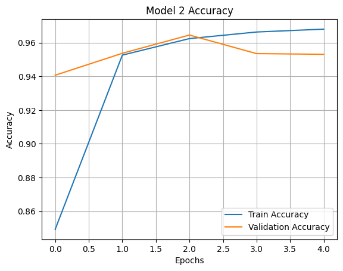

```python
plt.plot(history_model_2.history['accuracy'], label='Train Accuracy')
plt.plot(history_model_2.history['val_accuracy'], label='Validation Accuracy')
plt.title('Model 2 Accuracy')
plt.xlabel('Epochs')
plt.ylabel('Accuracy')
plt.legend()
plt.grid(True)
plt.show()
```

#### **Observations & Insights:**

The val_accuracy closely follows training accuracy implying that there is not any major overfitting issue.

```python
# Predictions
y_pred_prob = model_2.predict(test_generator)
y_pred = (y_pred_prob > 0.5).astype(int)

# True labels
y_true = test_generator.classes
```

```
163/163 ━━━━━━━━━━━━━━━━━━━━ 5s 26ms/step
```

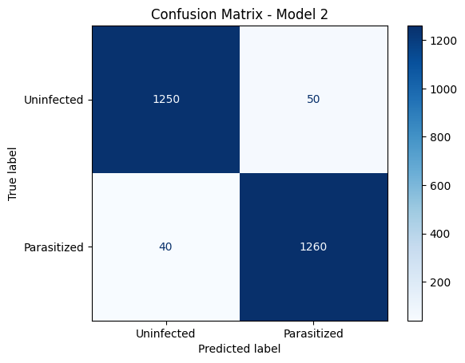

```python
from sklearn.metrics import ConfusionMatrixDisplay

cm = confusion_matrix(y_true, y_pred)

disp = ConfusionMatrixDisplay(
    confusion_matrix=cm,
    display_labels=labels_order
)

disp.plot(cmap='Blues')
plt.title('Confusion Matrix - Model 2')
plt.show()
```

```python
print(classification_report(
    y_true,
    y_pred_1,
    target_names=['Uninfected', 'Parasitized']
))
```

[output not shown]

#### **Observation & Insights:**

**Next Steps:**

In the next section of the notebook, pre-trained models are implemented to see if there is any change in the performance compared to model_2.

*Based on above it is concluded that even though model_1 and base_model perform well with the given dataset, model_2 is expected to perform better and is more robust.*

*In the next section it is noted if any of the two pre-trained models perform better than model_2.*

### **VGG-16 Pre-trained Model**

In this work, VGG16 is used as a feature extractor through transfer learning. The pretrained convolutional layers capture generic visual patterns such as edges, textures, and shapes, which are highly transferable to medical images like blood smears. A custom classification head is added on top of the frozen base network to adapt VGG16 to the binary malaria detection task.

```python
from tensorflow.keras import backend
backend.clear_session()
```

```python
from tensorflow.keras.applications import VGG16
from tensorflow.keras.layers import Dropout, Dense, Flatten

vgg_base = VGG16(
    weights='imagenet',
    include_top=False,
    input_shape=(96, 96, 3)
)
for layer in vgg_base.layers:
    layer.trainable = False

x = vgg_base.output
x = Flatten()(x)

x = Dense(256, activation='relu')(x)
x = Dropout(0.5)(x)

x = Dense(128, activation='relu')(x)
x = Dropout(0.3)(x)

output = Dense(1, activation='sigmoid')(x)
```

```
Downloading data from https://storage.googleapis.com/tensorflow/keras-applications/vgg16/vgg16_weights_tf_dim_ordering_tf_kernels_notop.h5
58889256/58889256 ━━━━━━━━━━━━━━━━━━━━ 0s 0us/step
```

```python
model_vgg16 = Model(inputs=vgg_base.input, outputs=output)
```

```python
model_vgg16.summary()
```

```
Model: "functional"
```

```
┏━━━━━━━━━━━━━━━━━━━━━━━━━━━━━━━━━┳━━━━━━━━━━━━━━━━━━━━━━━━┳━━━━━━━━━━━━━━━┓
┃ Layer (type)                    ┃ Output Shape           ┃       Param # ┃
┡━━━━━━━━━━━━━━━━━━━━━━━━━━━━━━━━━╇━━━━━━━━━━━━━━━━━━━━━━━━╇━━━━━━━━━━━━━━━┩
│ input_layer (InputLayer)        │ (None, 96, 96, 3)      │             0 │
├─────────────────────────────────┼────────────────────────┼───────────────┤
│ block1_conv1 (Conv2D)           │ (None, 96, 96, 64)     │         1,792 │
├─────────────────────────────────┼────────────────────────┼───────────────┤
│ block1_conv2 (Conv2D)           │ (None, 96, 96, 64)     │        36,928 │
├─────────────────────────────────┼────────────────────────┼───────────────┤
│ block1_pool (MaxPooling2D)      │ (None, 48, 48, 64)     │             0 │
├─────────────────────────────────┼────────────────────────┼───────────────┤
│ block2_conv1 (Conv2D)           │ (None, 48, 48, 128)    │        73,856 │
├─────────────────────────────────┼────────────────────────┼───────────────┤
│ block2_conv2 (Conv2D)           │ (None, 48, 48, 128)    │       147,584 │
├─────────────────────────────────┼────────────────────────┼───────────────┤
│ block2_pool (MaxPooling2D)      │ (None, 24, 24, 128)    │             0 │
├─────────────────────────────────┼────────────────────────┼───────────────┤
│ block3_conv1 (Conv2D)           │ (None, 24, 24, 256)    │       295,168 │
├─────────────────────────────────┼────────────────────────┼───────────────┤
│ block3_conv2 (Conv2D)           │ (None, 24, 24, 256)    │       590,080 │
├─────────────────────────────────┼────────────────────────┼───────────────┤
│ block3_conv3 (Conv2D)           │ (None, 24, 24, 256)    │       590,080 │
├─────────────────────────────────┼────────────────────────┼───────────────┤
│ block3_pool (MaxPooling2D)      │ (None, 12, 12, 256)    │             0 │
├─────────────────────────────────┼────────────────────────┼───────────────┤
│ block4_conv1 (Conv2D)           │ (None, 12, 12, 512)    │     1,180,160 │
├─────────────────────────────────┼────────────────────────┼───────────────┤
│ block4_conv2 (Conv2D)           │ (None, 12, 12, 512)    │     2,359,808 │
├─────────────────────────────────┼────────────────────────┼───────────────┤
│ block4_conv3 (Conv2D)           │ (None, 12, 12, 512)    │     2,359,808 │
├─────────────────────────────────┼────────────────────────┼───────────────┤
│ block4_pool (MaxPooling2D)      │ (None, 6, 6, 512)      │             0 │
├─────────────────────────────────┼────────────────────────┼───────────────┤
│ block5_conv1 (Conv2D)           │ (None, 6, 6, 512)      │     2,359,808 │
├─────────────────────────────────┼────────────────────────┼───────────────┤
│ block5_conv2 (Conv2D)           │ (None, 6, 6, 512)      │     2,359,808 │
├─────────────────────────────────┼────────────────────────┼───────────────┤
│ block5_conv3 (Conv2D)           │ (None, 6, 6, 512)      │     2,359,808 │
├─────────────────────────────────┼────────────────────────┼───────────────┤
│ block5_pool (MaxPooling2D)      │ (None, 3, 3, 512)      │             0 │
├─────────────────────────────────┼────────────────────────┼───────────────┤
│ flatten (Flatten)               │ (None, 4608)           │             0 │
├─────────────────────────────────┼────────────────────────┼───────────────┤
│ dense (Dense)                   │ (None, 256)            │     1,179,904 │
├─────────────────────────────────┼────────────────────────┼───────────────┤
│ dropout (Dropout)               │ (None, 256)            │             0 │
├─────────────────────────────────┼────────────────────────┼───────────────┤
│ dense_1 (Dense)                 │ (None, 128)            │        32,896 │
├─────────────────────────────────┼────────────────────────┼───────────────┤
│ dropout_1 (Dropout)             │ (None, 128)            │             0 │
├─────────────────────────────────┼────────────────────────┼───────────────┤
│ dense_2 (Dense)                 │ (None, 1)              │           129 │
└─────────────────────────────────┴────────────────────────┴───────────────┘
```

```
 Total params: 15,927,617 (60.76 MB)
```

```
 Trainable params: 1,212,929 (4.63 MB)
```

```
 Non-trainable params: 14,714,688 (56.13 MB)
```

```python
model_vgg16.compile(optimizer=Adam(learning_rate=0.0001), loss='binary_crossentropy', metrics=['accuracy'])
```

```python
es= EarlyStopping(monitor='val_loss', patience=3, mode= 'min', restore_best_weights=True, verbose=1)
mc= ModelCheckpoint('vgg16_best.h5', monitor='val_accuracy', mode= 'max', save_best_only=True, verbose=1)
```

```python
history_vgg16 = model_vgg16.fit(
    train_generator, #augmented data
    validation_data=val_generator,
    epochs=7,
    callbacks=[es, mc]
)
```

```
1248/1248 ━━━━━━━━━━━━━━━━━━━━ 0s 70ms/step - accuracy: 0.8046 - loss: 0.4097
Epoch 1: val_accuracy improved from -inf to 0.86075, saving model to vgg16_best.h5
```

```
WARNING:absl:You are saving your model as an HDF5 file via `model.save()` or `keras.saving.save_model(model)`. This file format is considered legacy. We recommend using instead the native Keras format, e.g. `model.save('my_model.keras')` or `keras.saving.save_model(model, 'my_model.keras')`.
```

```
1248/1248 ━━━━━━━━━━━━━━━━━━━━ 104s 79ms/step - accuracy: 0.8047 - loss: 0.4096 - val_accuracy: 0.8607 - val_loss: 0.3854
1248/1248 ━━━━━━━━━━━━━━━━━━━━ 0s 67ms/step - accuracy: 0.9245 - loss: 0.2057
Epoch 2: val_accuracy improved from 0.86075 to 0.91745, saving model to vgg16_best.h5
```

```
WARNING:absl:You are saving your model as an HDF5 file via `model.save()` or `keras.saving.save_model(model)`. This file format is considered legacy. We recommend using instead the native Keras format, e.g. `model.save('my_model.keras')` or `keras.saving.save_model(model, 'my_model.keras')`.
```

```
1248/1248 ━━━━━━━━━━━━━━━━━━━━ 90s 72ms/step - accuracy: 0.9245 - loss: 0.2057 - val_accuracy: 0.9175 - val_loss: 0.2190
1248/1248 ━━━━━━━━━━━━━━━━━━━━ 0s 70ms/step - accuracy: 0.9332 - loss: 0.1830
Epoch 3: val_accuracy improved from 0.91745 to 0.93128, saving model to vgg16_best.h5
```

```
WARNING:absl:You are saving your model as an HDF5 file via `model.save()` or `keras.saving.save_model(model)`. This file format is considered legacy. We recommend using instead the native Keras format, e.g. `model.save('my_model.keras')` or `keras.saving.save_model(model, 'my_model.keras')`.
```

```
1248/1248 ━━━━━━━━━━━━━━━━━━━━ 94s 76ms/step - accuracy: 0.9332 - loss: 0.1830 - val_accuracy: 0.9313 - val_loss: 0.1812
1248/1248 ━━━━━━━━━━━━━━━━━━━━ 0s 66ms/step - accuracy: 0.9395 - loss: 0.1681
Epoch 4: val_accuracy did not improve from 0.93128
1248/1248 ━━━━━━━━━━━━━━━━━━━━ 90s 72ms/step - accuracy: 0.9395 - loss: 0.1681 - val_accuracy: 0.9281 - val_loss: 0.1866
1248/1248 ━━━━━━━━━━━━━━━━━━━━ 0s 64ms/step - accuracy: 0.9411 - loss: 0.1649
Epoch 5: val_accuracy did not improve from 0.93128
1248/1248 ━━━━━━━━━━━━━━━━━━━━ 87s 70ms/step - accuracy: 0.9411 - loss: 0.1649 - val_accuracy: 0.9193 - val_loss: 0.2162
1248/1248 ━━━━━━━━━━━━━━━━━━━━ 0s 66ms/step - accuracy: 0.9430 - loss: 0.1571
Epoch 6: val_accuracy improved from 0.93128 to 0.93809, saving model to vgg16_best.h5
```

```
WARNING:absl:You are saving your model as an HDF5 file via `model.save()` or `keras.saving.save_model(model)`. This file format is considered legacy. We recommend using instead the native Keras format, e.g. `model.save('my_model.keras')` or `keras.saving.save_model(model, 'my_model.keras')`.
```

```
1248/1248 ━━━━━━━━━━━━━━━━━━━━ 90s 72ms/step - accuracy: 0.9430 - loss: 0.1571 - val_accuracy: 0.9381 - val_loss: 0.1642
1248/1248 ━━━━━━━━━━━━━━━━━━━━ 0s 65ms/step - accuracy: 0.9463 - loss: 0.1549
Epoch 7: val_accuracy did not improve from 0.93809
1248/1248 ━━━━━━━━━━━━━━━━━━━━ 88s 70ms/step - accuracy: 0.9463 - loss: 0.1549 - val_accuracy: 0.9377 - val_loss: 0.1642
Restoring model weights from the end of the best epoch: 6.
```

```python
model_vgg16 = load_model("vgg16_best.h5")
```

```
WARNING:absl:Compiled the loaded model, but the compiled metrics have yet to be built. `model.compile_metrics` will be empty until you train or evaluate the model.
```

```python
test_loss, test_acc = model_vgg16.evaluate(test_generator)
print(f"Test Accuracy: {test_acc:.4f}")
print(f"Test Loss: {test_loss:.4f}")
```

```
163/163 ━━━━━━━━━━━━━━━━━━━━ 7s 34ms/step - accuracy: 0.9399 - loss: 0.1338
Test Accuracy: 0.9515
Test Loss: 0.1291
```

#### **Observation & Insights:**

The accuracy is clearly less than 96% from model_2 with current one being 95%. The model is not performing as good as model_2 and is also occupying more memory resources.

The loss has also increased from 0.10 to 0.12.

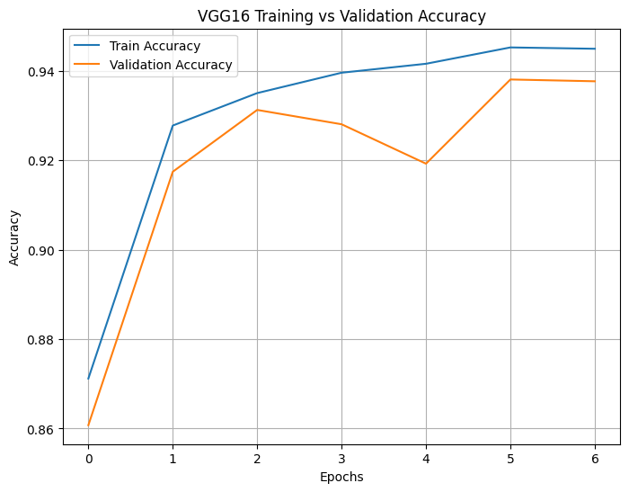

```python
plt.figure(figsize=(8,6))

plt.plot(history_vgg16.history['accuracy'], label='Train Accuracy')
plt.plot(history_vgg16.history['val_accuracy'], label='Validation Accuracy')

plt.title('VGG16 Training vs Validation Accuracy')
plt.xlabel('Epochs')
plt.ylabel('Accuracy')
plt.legend()
plt.grid(True)
plt.show()
```

#### **Observation & Insights:**

The dip in the graph at the 4th epoch explains the accuracy fall as well as loss increament.

The plot correctly provides visual presentation of the model training during each across, serving the purpose of this plot successfully.

```python
import numpy as np

test_generator.reset()

y_pred_prob = model_vgg16.predict(test_generator)
y_pred = (y_pred_prob > 0.5).astype(int).ravel()

y_true = test_generator.classes
```

```
163/163 ━━━━━━━━━━━━━━━━━━━━ 6s 30ms/step
```

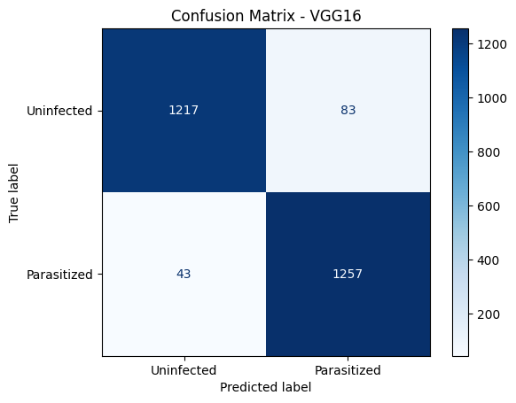

```python
from sklearn.metrics import confusion_matrix, ConfusionMatrixDisplay

cm = confusion_matrix(y_true, y_pred)

disp = ConfusionMatrixDisplay(
    confusion_matrix=cm,
    display_labels=labels_order
)

disp.plot(cmap='Blues')
plt.title('Confusion Matrix - VGG16')
plt.show()
```

```python
from sklearn.metrics import classification_report

print(classification_report(
    y_true,
    y_pred,
    target_names=['Uninfected', 'Parasitized']
))
```

```
              precision    recall  f1-score   support

  Uninfected       0.97      0.94      0.95      1300
 Parasitized       0.94      0.97      0.95      1300

    accuracy                           0.95      2600
   macro avg       0.95      0.95      0.95      2600
weighted avg       0.95      0.95      0.95      2600
```

#### **Observation & Insights:**

- There is clear alarming rise in the FN and FP, 43 and 83 respectively. The classification report also reports lower values in comparison to mdoel_2's performance.

**Implication and insight:**

Although VGG16 is a strong pretrained model, its features are learned from natural images (ImageNet), which differ significantly from microscopic blood cell images. Data augmentation further altered the appearance of cells, making it harder for VGG16’s pretrained filters to adapt, leading to higher false positives and false negatives compared to Model-2, which was trained directly on augmented malaria images from scratch

This **highlights a key limitation of transfer learning:** pretrained models do not always generalize well **compared to a CNN built from scratch** when the *target domain differs significantly* from the source domain, especially under aggressive augmentation.

**Next Steps:**

### **EfficientNetB0**

In this project, EfficientNetB0 is chosen as a **lightweight yet powerful transfer-learning model**, motivated by its *prior success in medical image classification tasks reported in literature* and its suitability for deployment in practical malaria screening systems.

A custom classification head is added on top of the pretrained EfficientNetB0 backbone to adapt the model to the binary task of parasitized vs uninfected red blood cell classification.

```python
from tensorflow.keras.applications import EfficientNetB0
from tensorflow.keras.layers import GlobalAveragePooling2D
```

```python
from tensorflow.keras.applications.efficientnet import preprocess_input

train_gen = ImageDataGenerator(
    preprocessing_function=preprocess_input,
    validation_split=0.2
)

test_gen = ImageDataGenerator(
    preprocessing_function=preprocess_input
)
```

```python
base_cnn = EfficientNetB0(
    weights="imagenet",
    include_top=False,
    input_shape=(96, 96, 3)
)

base_cnn.trainable = False  # warm-up phase

model_effnet = Sequential([
    base_cnn,
    GlobalAveragePooling2D(),
    BatchNormalization(),
    Dense(128),
    LeakyReLU(),
    Dense(1, activation='sigmoid')
])
```

```
Downloading data from https://storage.googleapis.com/keras-applications/efficientnetb0_notop.h5
16705208/16705208 ━━━━━━━━━━━━━━━━━━━━ 0s 0us/step
```

```python
model_effnet.summary()
```

```
Model: "sequential"
```

```
┏━━━━━━━━━━━━━━━━━━━━━━━━━━━━━━━━━┳━━━━━━━━━━━━━━━━━━━━━━━━┳━━━━━━━━━━━━━━━┓
┃ Layer (type)                    ┃ Output Shape           ┃       Param # ┃
┡━━━━━━━━━━━━━━━━━━━━━━━━━━━━━━━━━╇━━━━━━━━━━━━━━━━━━━━━━━━╇━━━━━━━━━━━━━━━┩
│ efficientnetb0 (Functional)     │ (None, 3, 3, 1280)     │     4,049,571 │
├─────────────────────────────────┼────────────────────────┼───────────────┤
│ global_average_pooling2d        │ (None, 1280)           │             0 │
│ (GlobalAveragePooling2D)        │                        │               │
├─────────────────────────────────┼────────────────────────┼───────────────┤
│ batch_normalization             │ (None, 1280)           │         5,120 │
│ (BatchNormalization)            │                        │               │
├─────────────────────────────────┼────────────────────────┼───────────────┤
│ dense_3 (Dense)                 │ (None, 128)            │       163,968 │
├─────────────────────────────────┼────────────────────────┼───────────────┤
│ leaky_re_lu (LeakyReLU)         │ (None, 128)            │             0 │
├─────────────────────────────────┼────────────────────────┼───────────────┤
│ dense_4 (Dense)                 │ (None, 1)              │           129 │
└─────────────────────────────────┴────────────────────────┴───────────────┘
```

```
 Total params: 4,218,788 (16.09 MB)
```

```
 Trainable params: 166,657 (651.00 KB)
```

```
 Non-trainable params: 4,052,131 (15.46 MB)
```

```python
model_effnet.compile(
    optimizer=Adam(1e-4),
    loss="binary_crossentropy",
    metrics=["accuracy"]
)

model_effnet.fit(
    train_generator,
    validation_data=val_generator,
    epochs=5
)
```

```
1248/1248 ━━━━━━━━━━━━━━━━━━━━ 145s 95ms/step - accuracy: 0.4991 - loss: 0.7138 - val_accuracy: 0.5015 - val_loss: 0.6901
1248/1248 ━━━━━━━━━━━━━━━━━━━━ 79s 63ms/step - accuracy: 0.5140 - loss: 0.7086 - val_accuracy: 0.5029 - val_loss: 0.6897
1248/1248 ━━━━━━━━━━━━━━━━━━━━ 78s 63ms/step - accuracy: 0.5173 - loss: 0.7045 - val_accuracy: 0.5011 - val_loss: 0.6914
1248/1248 ━━━━━━━━━━━━━━━━━━━━ 80s 64ms/step - accuracy: 0.5130 - loss: 0.7017 - val_accuracy: 0.5013 - val_loss: 0.6907
1248/1248 ━━━━━━━━━━━━━━━━━━━━ 80s 64ms/step - accuracy: 0.5175 - loss: 0.7007 - val_accuracy: 0.5099 - val_loss: 0.6879
```

```
<keras.src.callbacks.history.History at 0x7a33144154f0>
```

```python
base_cnn.trainable = True

model_effnet.compile(
    optimizer=Adam(1e-5),  # very small LR
    loss="binary_crossentropy",
    metrics=["accuracy"]
)

history_model_effnet= model_effnet.fit(
    train_generator,
    validation_data=val_generator,
    epochs=10
)
```

```
1248/1248 ━━━━━━━━━━━━━━━━━━━━ 224s 118ms/step - accuracy: 0.7666 - loss: 0.4848 - val_accuracy: 0.9183 - val_loss: 0.2120
1248/1248 ━━━━━━━━━━━━━━━━━━━━ 94s 75ms/step - accuracy: 0.9342 - loss: 0.1781 - val_accuracy: 0.9587 - val_loss: 0.1195
1248/1248 ━━━━━━━━━━━━━━━━━━━━ 95s 76ms/step - accuracy: 0.9448 - loss: 0.1576 - val_accuracy: 0.9561 - val_loss: 0.1459
1248/1248 ━━━━━━━━━━━━━━━━━━━━ 96s 77ms/step - accuracy: 0.9560 - loss: 0.1366 - val_accuracy: 0.9547 - val_loss: 0.1297
1248/1248 ━━━━━━━━━━━━━━━━━━━━ 142s 77ms/step - accuracy: 0.9632 - loss: 0.1175 - val_accuracy: 0.9621 - val_loss: 0.1135
1248/1248 ━━━━━━━━━━━━━━━━━━━━ 97s 78ms/step - accuracy: 0.9651 - loss: 0.1114 - val_accuracy: 0.9535 - val_loss: 0.1300
1248/1248 ━━━━━━━━━━━━━━━━━━━━ 97s 78ms/step - accuracy: 0.9656 - loss: 0.1060 - val_accuracy: 0.9565 - val_loss: 0.1266
1248/1248 ━━━━━━━━━━━━━━━━━━━━ 98s 79ms/step - accuracy: 0.9684 - loss: 0.0954 - val_accuracy: 0.9641 - val_loss: 0.1220
1248/1248 ━━━━━━━━━━━━━━━━━━━━ 99s 79ms/step - accuracy: 0.9687 - loss: 0.0952 - val_accuracy: 0.9547 - val_loss: 0.1404
1248/1248 ━━━━━━━━━━━━━━━━━━━━ 96s 77ms/step - accuracy: 0.9711 - loss: 0.0863 - val_accuracy: 0.9715 - val_loss: 0.0859
```

```python
test_loss, test_acc = model_effnet.evaluate(test_generator)
print(f"Test Accuracy: {test_acc:.4f}")
print(f"Test Loss: {test_loss:.4f}")
```

```
163/163 ━━━━━━━━━━━━━━━━━━━━ 11s 67ms/step - accuracy: 0.9796 - loss: 0.0647
Test Accuracy: 0.9800
Test Loss: 0.0642
```

#### **Observation & Insights:**

The accuracy of this model is 98% with augmentated data.

And the loss of the model is 0.06.

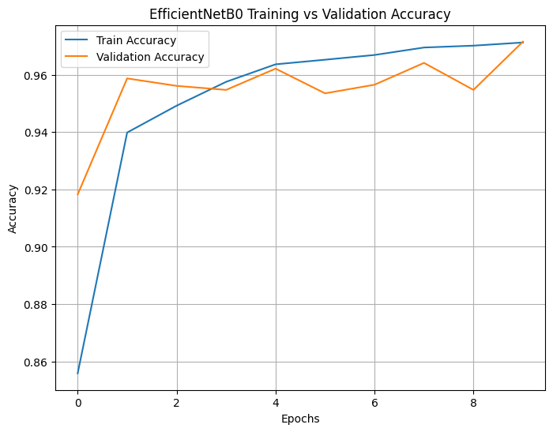

```python
plt.figure(figsize=(8,6))

plt.plot(history_model_effnet.history['accuracy'], label='Train Accuracy')
plt.plot(history_model_effnet.history['val_accuracy'], label='Validation Accuracy')

plt.title('EfficientNetB0 Training vs Validation Accuracy')
plt.xlabel('Epochs')
plt.ylabel('Accuracy')
plt.legend()
plt.grid(True)
plt.show()
```

#### **Observation & Insights:**

The val_accuracy follows and genralizes better learning with each epochs.

```python
y_pred_prob = model_effnet.predict(test_generator)
y_pred = (y_pred_prob > 0.5).astype(int)

y_true = test_generator.classes
```

```
163/163 ━━━━━━━━━━━━━━━━━━━━ 22s 91ms/step
```

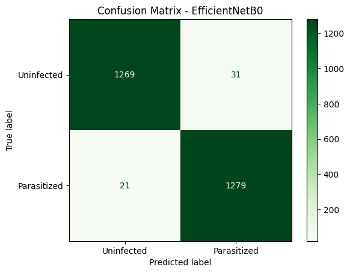

```python
cm = confusion_matrix(y_true, y_pred)

disp = ConfusionMatrixDisplay(
    confusion_matrix=cm,
    display_labels=labels_order
)

disp.plot(cmap='Greens')
plt.title('Confusion Matrix - EfficientNetB0')
plt.show()
```

```python
print(classification_report(
    y_true,
    y_pred,
    target_names=['Uninfected', 'Parasitized']
))
```

```
              precision    recall  f1-score   support

  Uninfected       0.98      0.98      0.98      1300
 Parasitized       0.98      0.98      0.98      1300

    accuracy                           0.98      2600
   macro avg       0.98      0.98      0.98      2600
weighted avg       0.98      0.98      0.98      2600
```

```python
model_effnet.save('efficientnetb0_malaria.h5')
```

```
WARNING:absl:You are saving your model as an HDF5 file via `model.save()` or `keras.saving.save_model(model)`. This file format is considered legacy. We recommend using instead the native Keras format, e.g. `model.save('my_model.keras')` or `keras.saving.save_model(model, 'my_model.keras')`.
```

#### **ROC Curve and checking the AUC**

Comparing Convolutional Neural Network (CNN) models using ROC (Receiver Operating Characteristic) curves is a standard method for evaluating and visualizing their classification performance. The primary metric for comparison is the Area Under the Curve (AUC), where a higher AUC value indicates superior performance

```python
test_generator.reset()
y_true = test_generator.classes
```

```python
y_prob_m1 = model_1.predict(test_generator).ravel()
y_prob_m2 = model_2.predict(test_generator).ravel()
y_prob_vgg = model_vgg16.predict(test_generator).ravel()
y_prob_effnet = model_effnet.predict(test_generator).ravel()
```

```
163/163 ━━━━━━━━━━━━━━━━━━━━ 3s 16ms/step
163/163 ━━━━━━━━━━━━━━━━━━━━ 3s 16ms/step
163/163 ━━━━━━━━━━━━━━━━━━━━ 4s 24ms/step
163/163 ━━━━━━━━━━━━━━━━━━━━ 3s 20ms/step
```

```python
from sklearn.metrics import roc_curve, auc

fpr_m1, tpr_m1, _ = roc_curve(y_true, y_prob_m1)
auc_m1 = auc(fpr_m1, tpr_m1)

fpr_m2, tpr_m2, _ = roc_curve(y_true, y_prob_m2)
auc_m2 = auc(fpr_m2, tpr_m2)

fpr_vgg, tpr_vgg, _ = roc_curve(y_true, y_prob_vgg)
auc_vgg = auc(fpr_vgg, tpr_vgg)

fpr_effnet, tpr_effnet, _ = roc_curve(y_true, y_prob_effnet)
auc_effnet = auc(fpr_effnet, tpr_effnet)
```

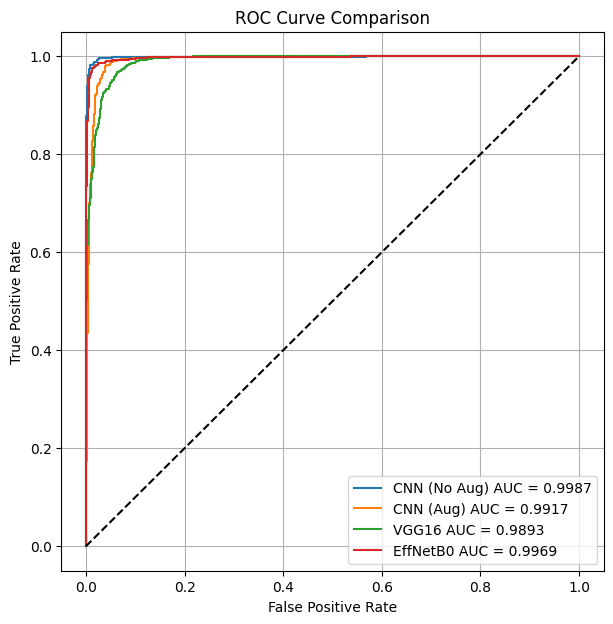

```python
plt.figure(figsize=(7,7))

plt.plot(fpr_m1, tpr_m1, label=f'CNN (No Aug) AUC = {auc_m1:.4f}')
plt.plot(fpr_m2, tpr_m2, label=f'CNN (Aug) AUC = {auc_m2:.4f}')
plt.plot(fpr_vgg, tpr_vgg, label=f'VGG16 AUC = {auc_vgg:.4f}')
plt.plot(fpr_effnet, tpr_effnet, label=f'EffNetB0 AUC = {auc_effnet:.4f}')
plt.plot()

plt.plot([0,1], [0,1], 'k--')

plt.xlabel('False Positive Rate')
plt.ylabel('True Positive Rate')
plt.title('ROC Curve Comparison')
plt.legend(loc='lower right')
plt.grid(True)

plt.show()
```

Clearly according to the graph EfficientNetB0 has a very comparable performance with model_1 however, EffcientNetB0 works with augmented data making it also more robust.

## **Recommendations for Implementation**

### Key Recommendations for Implementing the Proposed Solution

1. **Adopt EfficientNetB0 as the baseline deployment model** Based on comparative evaluation, EfficientNetB0 demonstrated the best balance between accuracy (98%), low false negatives (21), generalization on augmented data, and manageable model size (48.6 MB). It is therefore recommended as the core diagnostic model for real-world malaria screening applications.
2. **Deploy the model on edge devices using post-training optimization techniques** Direct deployment of a 48.6 MB model on microcontrollers (such as STM32 F/H series boards with ~564 KB–1.4 MB RAM) is infeasible. Hence, **model pruning and quantization** should be applied to reduce memory footprint and inference latency while preserving diagnostic accuracy.
3. **Integrate the model with smartphone-based microscopy systems** The most practical deployment strategy is to run the optimized model on low-cost Android smartphones attached to basic microscope eyepieces, enabling offline inference in remote clinical settings.
4. **Use augmented data during training to improve real-world robustness** Since clinical data is noisy and variable, future retraining should prioritize augmented datasets to avoid overfitting and ensure reliable performance under field conditions.

### Key Actionables for Stakeholders, Expected Benefits, and Costs

| Stakeholder | Key Actionables | Expected Benefits | Expected Costs |
| --- | --- | --- | --- |
| Healthcare Providers | Adopt smartphone-based screening tools | Faster diagnosis, reduced dependency on lab infrastructure | Initial device procurement |
| NGOs & Public Health Agencies | Deploy systems in remote clinics | Improved early detection, reduced mortality | Training and logistics |
| ML Engineers | Apply pruning, quantization, and benchmarking | Smaller models, faster inference | Engineering effort |
| Policy Makers | Approve AI-assisted diagnostics | Scalable malaria screening | Regulatory evaluation |

### Key Risks and Challenges

1. **False Negatives in High-Stakes Medical Diagnosis** Despite strong performance, even a small number of false negatives can have serious consequences. Continuous monitoring and threshold tuning are required.
2. **Domain Shift Between Training Data and Real Clinical Images** Differences in staining quality, microscope resolution, and lighting conditions may reduce model performance in practice.
3. **Hardware Constraints in Ultra-Low-Power Devices** While smartphones are feasible, direct deployment on microcontrollers remains challenging without aggressive optimization.
4. **Regulatory and Ethical Constraints** AI-based medical tools require validation, explainability, and approval from health authorities before clinical adoption.

### Further Analysis and Future Work

1. **Model Compression Techniques** Apply **pruning, post-training quantization (INT8), and knowledge distillation** to reduce EfficientNetB0’s size, enabling deployment on constrained edge devices.
2. **Clinical Validation Studies** Test the model on real blood smear samples collected from multiple regions to evaluate generalization and bias.
3. **Explainability and Trust Building** Integrate techniques such as **Grad-CAM** to visualize infected regions and increase clinician trust in predictions.
4. **Comparison with Ultra-Light Models** Evaluate architectures such as MobileNetV3 or custom shallow CNNs for extreme low-resource environments.
5. **End-to-End Deployment Pipeline** Develop a complete pipeline including image acquisition, preprocessing, inference, and result reporting for field deployment.

### Final Implementation Perspective

While EfficientNetB0 cannot be directly deployed on microcontrollers due to severe memory limitations, its performance makes it an excellent candidate for **optimized edge deployment**. Through pruning and quantization, the model can be significantly reduced in size while maintaining diagnostic reliability. When combined with smartphone-based microscopy, this solution provides a scalable, robust, and practical approach to malaria detection in resource-limited settings, directly addressing critical gaps in current diagnostic systems.